Alexander Hyde  
Phys 434 AB  
Partner: Max Wang

# Lab 6

```python
%matplotlib inline
import numpy as np
import math
import matplotlib
import matplotlib.pyplot as plt
import scipy
from scipy import stats
import random
plt.rcParams["figure.figsize"] = (22,8)
```

## Problem 1

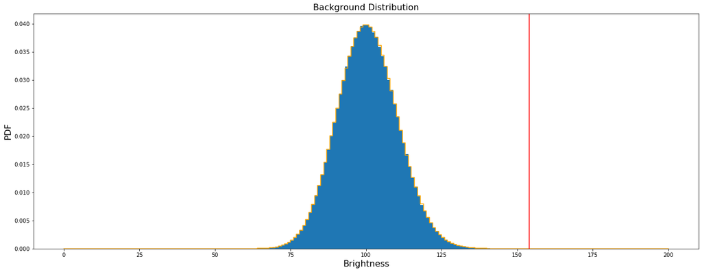

```
Sigma 5 = 154.0
```

```python
x = np.linspace(0,200,201)
y = stats.poisson.pmf(x,100)
bkgd = stats.poisson.rvs(100,0,1000000)
probS5 = 1 - stats.norm.cdf(5,0,1)
sig5 = stats.poisson.ppf(1-probS5,100)

plt.subplots(1,1)
plt.step(x,y,where="post",color="Orange")
plt.hist(bkgd,bins=x,density=True)
plt.axvline(x=sig5,color="Red")
plt.xlabel("Brightness",fontsize=16)
plt.ylabel("PDF",fontsize=16)
plt.title("Background Distribution",fontsize=16)
plt.show()

print("Sigma 5 = " + str(sig5))
```

Here's both a Poisson pdf of the background, and a histogram of a million samples of the background taken with a Poisson distribution. For the rest of this lab, I'll be using this as my background distribution. Also, I plotted the brightness of 5 Sigma discovery as a red line.

## Problem 2

**a.**

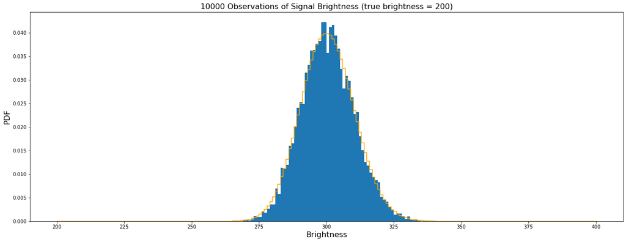

```
Observed Brightness Mean = 300.0744
Observed Brightness S. Deviation = 9.858477752592451
```

```python
random.seed()
signal1 = 200
x_s = x + signal1
od = []
Pds = stats.poisson.pmf(x_s,100,signal1)

def injectSignal(s):
    return (s + bkgd[random.randrange(0,len(bkgd))])

for i in range(10000):
    od.append(injectSignal(signal1))

plt.subplots(1,1)
plt.hist(od,bins=x_s,density=True)
plt.step(x_s,Pds,where="post",color="Orange")
plt.xlabel("Brightness",fontsize=16)
plt.ylabel("PDF",fontsize=16)
plt.title("10000 Observations of Signal Brightness (true brightness = 200)",fontsize=16)
plt.show()

def MeanAndSDev(a):
    mean = sum(a)/len(a)
    squares = np.square(np.add(a,-mean))
    sDev = math.sqrt(sum(squares)/(len(squares)-1))
    return mean,sDev

mean,sDev = MeanAndSDev(od)
print("Observed Brightness Mean = " + str(mean))
print("Observed Brightness S. Deviation = " + str(sDev))
```

I took 10000 observations of how bright my machinery read the signal 200 as by associating it to random numbers from the Poisson background. After plotting these 10k observations as a histogram, you can easily see how it takes the shape of a Poisson of the exact same width as the background, only shifted 200 units to the right. You can easily confirm this with numbers as the observed mean is effectively the mean of the Poisson background 100 plus the signal 200, and the observed standard deviation is effectively the same as the background, being close to 10.

This histogram represents a distribution of what brightness the machinery would see if a signal of 200 came into it; literally speaking, if 10000 signals of 200 came into it.

**b.** The observed brightness is biased towards being brighter than the true signal brightness. You can see this in the histogram, as its mean is about 100 units higher than the true signal of 200 units. The observed brightness distribution is likely symmetric about its own mean however, as it still follows a Poisson shape, but the histogram of course has a few asymmetric flaws from random sampling.

## Problem 3

**a.** Now I'm going to do the same type of injection that I did in Problem 2, but for a huge amount of signals. To be exact, I'll make a million random signals between 200 and 600, and then add those to the one million background readings (without a signal) that I had. Then I'll plot these signals vs. observed readings as a 2D histogram, and analyze it from there.

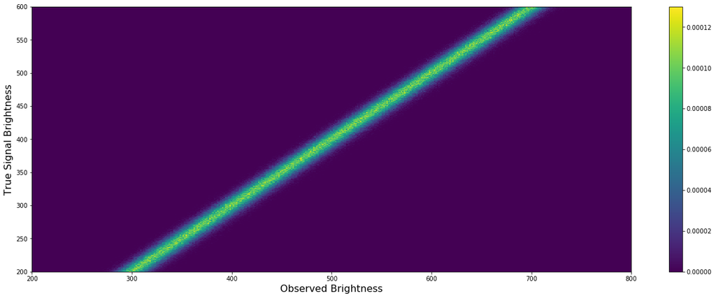

```python
signal = stats.uniform.rvs(200,400,1000000)
data = bkgd + signal

plt.subplots(1,1)
signalBins = np.linspace(200,600,401)
dataBins = np.linspace(200,800,601)
plt.hist2d(data,signal,bins=[dataBins,signalBins],density=True)
plt.colorbar()
plt.xlabel("Observed Brightness",fontsize=16)
plt.ylabel("True Signal Brightness",fontsize=16)
plt.show()
```

**b.**

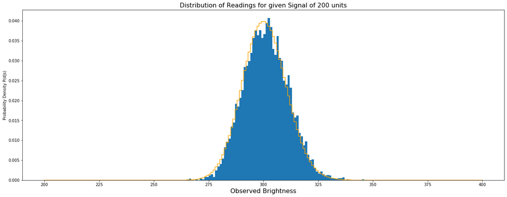

```
Observed Brightness Mean = 301.19574197419877
Observed Brightness S. Deviation = 10.178828091770836
```

```python
def sliceSignal(s):
    s_d = []
    for i in range(len(signal)):
        if (s-2.5)<=signal[i] and signal[i]<(s+2.5):
            s_d.append(data[i])
    return s_d

sData = sliceSignal(signal1)
sX = np.linspace(signal1,200+signal1,201)
plt.subplots(1,1)
plt.hist(sData,bins=sX,density=True)

Pds = stats.poisson.pmf(sX,100,signal1)
plt.step(sX,Pds,where="post",color="Orange")
plt.xlabel("Observed Brightness",fontsize=16)
plt.ylabel("Probability Density P(d|s)")
plt.title("Distribution of Readings for given Signal of " + str(signal1) + " units",fontsize=16)
plt.show()

mean,sDev = MeanAndSDev(sData)
print("Observed Brightness Mean = " + str(mean))
print("Observed Brightness S. Deviation = " + str(sDev))
```

Shape-wise, you can both visually and numerically compare this to Problem 2a's graph, as they both fit decently well under the same Poisson fit, and they both have nearly the same mean and standard deviation.

**c.**

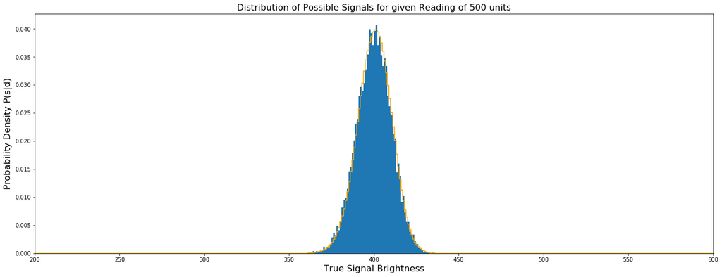

```
Observed Brightness Mean = 400.095085753343
Observed Brightness S. Deviation = 10.166808732282218
```

```python
data1 = 500

def sliceData(s):
    s_s = []
    for i in range(len(data)):
        if (s-2.5)<=data[i] and data[i]<(s+2.5):
            s_s.append(signal[i])
    return s_s

sSignal = sliceData(data1)
sS = np.linspace(200,600,401)
Psd = np.multiply(stats.poisson.pmf(data1,100,sS),stats.uniform.pdf(sS,200,400))
Psd = Psd/sum(Psd)

plt.subplots(1,1)
plt.hist(sSignal,bins=sS,density=True)
plt.step(sS,Psd,where="post",color="Orange")
plt.xlim([200,600])
plt.xlabel("True Signal Brightness",fontsize=16)
plt.ylabel("Probability Density P(s|d)",fontsize=16)
plt.title("Distribution of Possible Signals for given Reading of " + str(data1) + " units",fontsize=16)
plt.show()

mean,sDev = MeanAndSDev(sSignal)
print("Observed Brightness Mean = " + str(mean))
print("Observed Brightness S. Deviation = " + str(sDev))
```

Now I took every data reading I had that was within 2.5 units of 500 and plotted the true signals they were associated to onto a histogram. In this case, I'm now taking a vertical slice of 5 units width out of the 2D histogram at the observed brightness 500. I also plotted a new pdf over this distribution, which I derived using Bayes Theorem.

This histogram represents the distribution of all of the true signals received when my machine read a brightness close to 500 units. However, the Poisson pdf I plotted represents the probability distribution of what signals could have been interpreted as 500 units by the machine.

**d.**

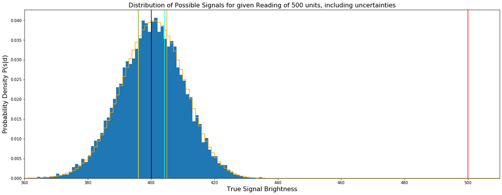

```
Symmetry of Distribution (1 Sigma) = 98.0667%
Symmetry of PDF (1 Sigma) = 125.0%
```

```python
sSignal.sort()
sig1 = 1 - stats.norm.cdf(1,0,1)
def sumForPPF(s_list,s_range,s_pList):
    s_total = sum(s_list)
    s_diff = np.diff(s_list)[0]
    s_area = 0
    s_uI = 0
    for i in s_range:
        if s_pList is None: # Histogram-like data
            s_area = s_area + s_list[i] / s_total
        else: # PDF-like data
            s_area = s_area + s_diff * s_pList[i]
        if s_area >= sig1:
            s_uI = i
            break
    return s_uI

def getIndexAfter(s_list,s_mean):
    s_mI = 0
    for i in range(len(sSignal)):
        if s_list[i] >= s_mean:
            s_mI = i
            break
    return s_mI

s_mean = sum(sSignal)/len(sSignal)
s_mI = getIndexAfter(sSignal,s_mean)
s_uL = sSignal[sumForPPF(sSignal,range(s_mI-1,-1,-1),None)]
s_uR = sSignal[sumForPPF(sSignal,range(s_mI,len(sSignal),1),None)]
s_symm = (s_uR - s_mean) / (s_mean - s_uL)

Psd_mean = sum(np.multiply(Psd,sS))
Psd_mI = getIndexAfter(sS,Psd_mean)
Psd_uL = sS[sumForPPF(sS,range(Psd_mI-1,-1,-1),Psd)]
Psd_uR = sS[sumForPPF(sS,range(Psd_mI,len(sS),1),Psd)]
Psd_symm = (Psd_uR - Psd_mean) / (Psd_mean - Psd_uL)

plt.subplots(1,1)
plt.hist(sSignal,bins=sS,density=True)
plt.step(sS,Psd,where="post",color="Orange")
plt.xlim([360,510])
plt.axvline(x=data1,color="Red")
plt.axvline(x=s_mean,color="Black")
plt.axvline(x=s_uL,color="Cyan")
plt.axvline(x=s_uR,color="Cyan")
plt.axvline(x=Psd_uL,color="Orange")
plt.axvline(x=Psd_uR,color="Orange")
plt.xlabel("True Signal Brightness",fontsize=16)
plt.ylabel("Probability Density P(s|d)",fontsize=16)
plt.title("Distribution of Possible Signals for given Reading of " + str(data1) + " units, including uncertainties",fontsize=16)
plt.show()

print("Symmetry of Distribution (1 Sigma) = " + str(np.round(s_symm,6)*100) + "%")
print("Symmetry of PDF (1 Sigma) = " + str(np.round(Psd_symm,6)*100) + "%")
```

I replotted the same plot from before, but zoomed in. The red line is the reading the machine took, being 500 units. The black line is the mean of the distribution. The cyan lines are the 1 Sigma uncertainty positions of the distribution. The vertical orange lines are the 1 Sigma uncertainty positions of the Bayes Theorem pdf. Due to the non-continuous nature of the pdf, the uncertainty lines of the pdf can easily be off by 1. Because of this, I believe that the distribution uncertainty points are more accurate than the pdf uncertainty points, since the massive amount of samples in the distribution increases its sensitivity, whereas the pdf's sensitivity is limited to integers due to its Poisson nature. This can also be seen in the symmetry estimations I took.

**e.**

First, a definition for my "symmetry" numbers: $Symmetry = \frac{x_{right} - x_{mean}}{x_{mean} - x_{left}}$, where x<sub>right</sub> is the uncertainty position on the right, and x<sub>left</sub> is the uncertainty position on the left. If the symmetry is greater than 1, the distribution is weighted more on the left, and if it's less than 1, it's weighted more on the right, and the closer it is to 1, the more symmetric the distribution is.

On a practical level, I'd consider this distribution pretty much symmetric, since its symmetry numbers are fairly close to 1. Technically speaking, **it won't be symmetric** even after taking infinity random samples, since the background is based on a Poisson with μ = 100, and the Poisson pdf has a shape that becomes very asymmetric when μ < 1, but becomes more symmetric and Gaussian-like (Central Limit Theorem) for larger values of μ. A Poisson distribution would only be exactly symmetric when its average μ is infinity. If you have an non-infinite, but huge-μ Poisson, then taking an infinite number of random samples will serve to highlight its precise asymmetry.

One thing to note here is that the mean of the distribution of signals that gave the machine a reading near 500 is around 400, making the readings **biased** towards being greater than the actual signals by around 100 units. This makes sense since even with no signal, the background readings taken by the machine have a mean of 100 units, so it naturally reads a static extra brightness of 100 units from anything.